# Assignment1

Paul Weissburg

May 15, 2019

- library(dplyr)
- library(tidyverse)
- library(lubridate)

### 1. Load data into R

Create temp file in WD

```r
temp <- tempfile()
```

Download file from URL to temp file

```r
download.file("https://d396qusza40orc.cloudfront.net/repdata%2Fdata%2Factivity.zip",temp)
```

Load data into R

```r
data <- as.tbl(read.csv(unz(temp, "activity.csv")))
```

Remove temp file

```r
unlink(temp)
```

### 2. Histogram of # of steps taken each day

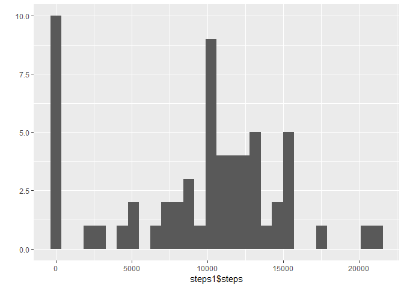

```r
steps1 <- data %>%
          group_by(date) %>%
          summarise(sum(steps,na.rm = TRUE))
names(steps1) <- c("date","steps")
qplot(steps1$steps,bins=30)
```

### 3. Median and mean of steps taken each day

```r
summary(steps1$steps)
```

```
##    Min. 1st Qu.  Median    Mean 3rd Qu.    Max.
##       0    6778   10395    9354   12811   21194
```

median = 10395; mean = 9354

### 4. Time series plot of number of steps taken

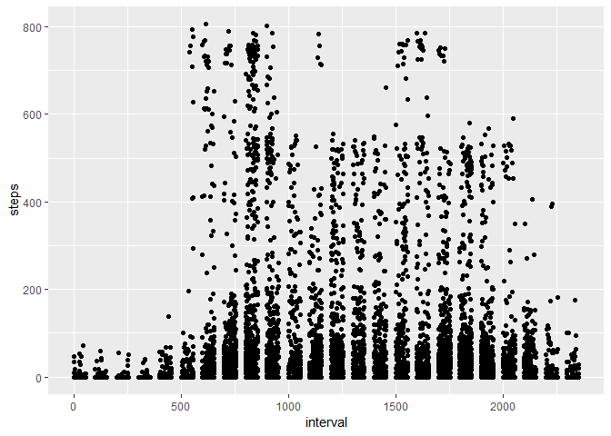

```r
dataNArm <- data[!is.na(data$steps),]
ggplot(dataNArm, aes(interval,steps))+geom_point()
```

### 5. The 5-minute interval that, on average, contains the maximum number of steps

```r
filter(data, data$steps == max(data$steps,na.rm = TRUE))
```

```
## # A tibble: 1 x 3
##   steps date       interval
##   <int> <fct>         <int>
## 1   806 2012-11-27      615
```

### 6. Imputing Missing Values

6a. Calculate and report the total number of missing values in the dataset

```r
sum(is.na(data$steps))
```

```
## [1] 2304
```

6b. Devise a strategy to impute NA values: Use median for each interval  
6c. Create imputed data sets

```r
dataNew <- data %>%
  group_by(interval) %>%
  mutate(median = median(steps,na.rm = TRUE))%>%
  mutate(steps2 = case_when(is.na(steps) ~ median,!is.na(steps) ~ steps))%>%
  mutate(day = weekdays(as.Date(date)))%>%
  mutate(weekend = case_when(day == "Saturday" | day == "Sunday" ~ "Weekend",
                             TRUE ~ "Weekday"))
dataNew$weekend <- factor(dataNew$weekend,levels = c("Weekday","Weekend"))

dataWeekend <- group_by(dataNew,interval,weekend)%>%
  summarise(mean = mean(steps2))

dataNew2 <- group_by(dataNew,date)%>%
  summarise(sum = sum(steps2))
```

6d. Make a histogram with imputed data

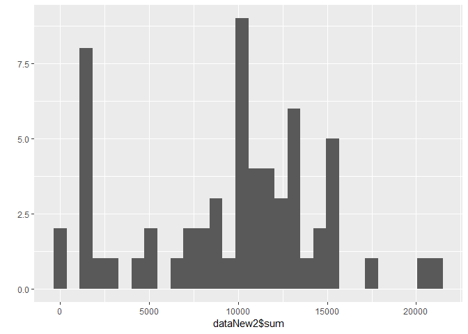

```r
qplot(dataNew2$sum,bins = 30)
```

6e. Find median and mean for imputed data

```r
summary(dataNew2$sum)
```

```
##    Min. 1st Qu.  Median    Mean 3rd Qu.    Max.
##      41    6778   10395    9504   12811   21194
```

median = 10395 mean = 9503.869

6f. The median is the same as the non-imputed calculation but the mean is higher.

### 7. What is the average daily activity pattern?

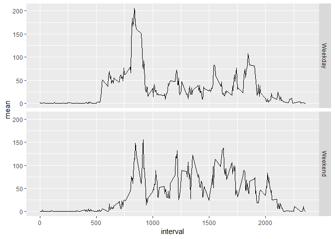

```r
gg <- ggplot(dataWeekend,aes(interval,mean))
gg + geom_line()+facet_grid(weekend~.)
```

Which 5-minute interval, on average across all the days in the dataset, contains the maximum number of steps?

```r
dataMean <- group_by(dataNew,interval)%>%
  summarise(mean = mean(steps2))
dataMean[dataMean$mean == max(dataMean$mean),]
```

```
## # A tibble: 1 x 2
##   interval  mean
##      <int> <dbl>
## 1      835  182.
```

Interval 835 with mean 182 *Calculated with imputed data*